# Lab Assignment 6

#### This Lab task is to completed individually, Please Add your Name and ID Below, please comment your code thoroughly and name your variables wisely. (Grade out of 23, 3 marks for commented organized code.)

- Name: Paras Rupani
- ID: 8961758

### Question 1- DATA INTEGRATION: (5)

Check the files inside microbiome folder, (MID1, MID2, ... , MID9.xls files), you need to combine those files into single dataframe.  
Then You will need to add to this dataframe the relevant metadata information from metadata.csv  
Each folder represents information from different bacteria, MID1, MID2, ...  
**Inspect the files before answering the question**

### Importing

```python
# Importing pandas to work with datset
import pandas as pd
```

## Loading Dataset

```python
# Initializing empty array of dataframes
dfs = []

for i in range(1, 10): # 10 as we have: 9 files
    # reading dataframe each iteration 9 times
    df = pd.read_excel(f"./data/microbiome/MID{i}.xls", header=None)
    df.columns = ["Bacteria", "Count"]

    # adding it to the array
    dfs.append(df)

    # adding column BARCODE filled with value of the file name
    dfs[i-1]['BARCODE'] = f'MID{i}'
```

## Combining Datasets

```python
# Concatenating all the MID files
data = pd.concat(dfs)

data
```

|  | Bacteria | Count | BARCODE |
| --- | --- | --- | --- |
| 0 | Archaea "Crenarchaeota" Thermoprotei Desulfurococcales Desulfurococcaceae Ignisphaera | 7 | MID1 |
| 1 | Archaea "Crenarchaeota" Thermoprotei Desulfurococcales Pyrodictiaceae Pyrolobus | 2 | MID1 |
| 2 | Archaea "Crenarchaeota" Thermoprotei Sulfolobales Sulfolobaceae Stygiolobus | 3 | MID1 |
| 3 | Archaea "Crenarchaeota" Thermoprotei Thermoproteales Thermofilaceae Thermofilum | 3 | MID1 |
| 4 | Archaea "Euryarchaeota" "Methanomicrobia" Methanocellales Methanocellaceae Methanocella | 7 | MID1 |
| ... | ... | ... | ... |
| 276 | Bacteria "Thermotogae" Thermotogae Thermotogales Thermotogaceae Geotoga | 43 | MID9 |
| 277 | Bacteria "Thermotogae" Thermotogae Thermotogales Thermotogaceae Kosmotoga | 16 | MID9 |
| 278 | Bacteria "Verrucomicrobia" Opitutae Opitutales Opitutaceae Opitutus | 1 | MID9 |
| 279 | Bacteria Cyanobacteria Cyanobacteria Chloroplast Chlorarachniophyceae | 1 | MID9 |
| 280 | Bacteria Cyanobacteria Cyanobacteria Chloroplast Streptophyta | 10 | MID9 |

2396 rows × 3 columns

```python
# reading metadata
meta_data = pd.read_csv("./data/microbiome/metadata.csv")

meta_data
```

|  | BARCODE | GROUP | SAMPLE |
| --- | --- | --- | --- |
| 0 | MID1 | EXTRACTION CONTROL | NaN |
| 1 | MID2 | NEC 1 | tissue |
| 2 | MID3 | Control 1 | tissue |
| 3 | MID4 | NEC 2 | tissue |
| 4 | MID5 | Control 2 | tissue |
| 5 | MID6 | NEC 1 | stool |
| 6 | MID7 | Control 1 | stool |
| 7 | MID8 | NEC 2 | stool |
| 8 | MID9 | Control 2 | stool |

## Merging into Single DataFrame

```python
# merging metadata with the combined MID dataframe
# pd.merge handles the merge as it has the common column - BARCODE
meta_data_merge = pd.merge(data, meta_data)

meta_data_merge
```

|  | Bacteria | Count | BARCODE | GROUP | SAMPLE |
| --- | --- | --- | --- | --- | --- |
| 0 | Archaea "Crenarchaeota" Thermoprotei Desulfurococcales Desulfurococcaceae Ignisphaera | 7 | MID1 | EXTRACTION CONTROL | NaN |
| 1 | Archaea "Crenarchaeota" Thermoprotei Desulfurococcales Pyrodictiaceae Pyrolobus | 2 | MID1 | EXTRACTION CONTROL | NaN |
| 2 | Archaea "Crenarchaeota" Thermoprotei Sulfolobales Sulfolobaceae Stygiolobus | 3 | MID1 | EXTRACTION CONTROL | NaN |
| 3 | Archaea "Crenarchaeota" Thermoprotei Thermoproteales Thermofilaceae Thermofilum | 3 | MID1 | EXTRACTION CONTROL | NaN |
| 4 | Archaea "Euryarchaeota" "Methanomicrobia" Methanocellales Methanocellaceae Methanocella | 7 | MID1 | EXTRACTION CONTROL | NaN |
| ... | ... | ... | ... | ... | ... |
| 2391 | Bacteria "Thermotogae" Thermotogae Thermotogales Thermotogaceae Geotoga | 43 | MID9 | Control 2 | stool |
| 2392 | Bacteria "Thermotogae" Thermotogae Thermotogales Thermotogaceae Kosmotoga | 16 | MID9 | Control 2 | stool |
| 2393 | Bacteria "Verrucomicrobia" Opitutae Opitutales Opitutaceae Opitutus | 1 | MID9 | Control 2 | stool |
| 2394 | Bacteria Cyanobacteria Cyanobacteria Chloroplast Chlorarachniophyceae | 1 | MID9 | Control 2 | stool |
| 2395 | Bacteria Cyanobacteria Cyanobacteria Chloroplast Streptophyta | 10 | MID9 | Control 2 | stool |

2396 rows × 5 columns

### Question 2- Feature Engineering - Attribute Correlation (15)

- Load the file income_data.csv, inspect the columns.
- Determine if race and education features have a statistical relationship.
- Explain and conclude your findings (7 till here)
- Inspect the dataset carefully and create an Indicator Feature (0/1) --(3 marks here)
- Inspect the dataset carefully and create an Interaction Feature (Additional feature engineered from your dataset)-- (3 marks here)  
  **The features you create must be resonable, please add an explanation to explain why did you chose those features** (2)

```python
# importing required libraries
from scipy.stats import chi2_contingency
import seaborn as sns
import matplotlib.pyplot as plt
```

## Loading Dataset

```python
# Reading the dataset
income_data = pd.read_csv('./data/income_data.csv')

# Inspecting columns
income_data
```

|  | age | workclass | fnlwgt | education | educational-num | marital-status | occupation | relationship | race | gender | capital-gain | capital-loss | hours-per-week | native-country | income |
| --- | --- | --- | --- | --- | --- | --- | --- | --- | --- | --- | --- | --- | --- | --- | --- |
| 0 | 25 | Private | 226802 | 11th | 7 | Never-married | Machine-op-inspct | Own-child | Black | Male | 0 | 0 | 40 | United-States | <=50K |
| 1 | 38 | Private | 89814 | HS-grad | 9 | Married-civ-spouse | Farming-fishing | Husband | White | Male | 0 | 0 | 50 | United-States | <=50K |
| 2 | 28 | Local-gov | 336951 | Assoc-acdm | 12 | Married-civ-spouse | Protective-serv | Husband | White | Male | 0 | 0 | 40 | United-States | >50K |
| 3 | 44 | Private | 160323 | Some-college | 10 | Married-civ-spouse | Machine-op-inspct | Husband | Black | Male | 7688 | 0 | 40 | United-States | >50K |
| 4 | 18 | ? | 103497 | Some-college | 10 | Never-married | ? | Own-child | White | Female | 0 | 0 | 30 | United-States | <=50K |
| ... | ... | ... | ... | ... | ... | ... | ... | ... | ... | ... | ... | ... | ... | ... | ... |
| 48837 | 27 | Private | 257302 | Assoc-acdm | 12 | Married-civ-spouse | Tech-support | Wife | White | Female | 0 | 0 | 38 | United-States | <=50K |
| 48838 | 40 | Private | 154374 | HS-grad | 9 | Married-civ-spouse | Machine-op-inspct | Husband | White | Male | 0 | 0 | 40 | United-States | >50K |
| 48839 | 58 | Private | 151910 | HS-grad | 9 | Widowed | Adm-clerical | Unmarried | White | Female | 0 | 0 | 40 | United-States | <=50K |
| 48840 | 22 | Private | 201490 | HS-grad | 9 | Never-married | Adm-clerical | Own-child | White | Male | 0 | 0 | 20 | United-States | <=50K |
| 48841 | 52 | Self-emp-inc | 287927 | HS-grad | 9 | Married-civ-spouse | Exec-managerial | Wife | White | Female | 15024 | 0 | 40 | United-States | >50K |

48842 rows × 15 columns

## Inspecting

```python
# Inspecting
income_data.info()
```

```
<class 'pandas.core.frame.DataFrame'>
RangeIndex: 48842 entries, 0 to 48841
Data columns (total 15 columns):
 #   Column           Non-Null Count  Dtype
---  ------           --------------  -----
 0   age              48842 non-null  int64
 1   workclass        48842 non-null  object
 2   fnlwgt           48842 non-null  int64
 3   education        48842 non-null  object
 4   educational-num  48842 non-null  int64
 5   marital-status   48842 non-null  object
 6   occupation       48842 non-null  object
 7   relationship     48842 non-null  object
 8   race             48842 non-null  object
 9   gender           48842 non-null  object
 10  capital-gain     48842 non-null  int64
 11  capital-loss     48842 non-null  int64
 12  hours-per-week   48842 non-null  int64
 13  native-country   48842 non-null  object
 14  income           48842 non-null  object
dtypes: int64(6), object(9)
memory usage: 5.6+ MB
```

We can see that we have only int64 (6 cols), object (9 cols) datatypes in the dataset.

Initially, it looks that the dataset has appropriate datatypes in each column

## Relationship between Race and Education

```python
education_race = pd.crosstab(income_data['race'], income_data['education'])
education_race
```

| education race | 10th | 11th | 12th | 1st-4th | 5th-6th | 7th-8th | 9th | Assoc-acdm | Assoc-voc | Bachelors | Doctorate | HS-grad | Masters | Preschool | Prof-school | Some-college |
| --- | --- | --- | --- | --- | --- | --- | --- | --- | --- | --- | --- | --- | --- | --- | --- | --- |
| Amer-Indian-Eskimo | 22 | 26 | 5 | 4 | 2 | 10 | 9 | 13 | 31 | 29 | 3 | 176 | 13 | 1 | 2 | 124 |
| Asian-Pac-Islander | 16 | 27 | 15 | 10 | 28 | 14 | 10 | 49 | 53 | 408 | 46 | 336 | 140 | 7 | 58 | 302 |
| Black | 182 | 252 | 105 | 24 | 41 | 90 | 111 | 161 | 165 | 504 | 16 | 1780 | 143 | 12 | 21 | 1078 |
| Other | 11 | 22 | 17 | 13 | 23 | 23 | 15 | 10 | 9 | 50 | 3 | 105 | 13 | 2 | 5 | 85 |
| White | 1158 | 1485 | 515 | 196 | 415 | 818 | 611 | 1368 | 1803 | 7034 | 526 | 13387 | 2348 | 61 | 748 | 9289 |

```python
chi_square, p, d_o_f, expected = chi2_contingency(education_race)

# Checking for a relationship
if p < 0.05:
    print(f"There is a statistical relation between race and education with a significane of {p:.1e}")
else:
    print(f"There is no statistical relation between race and education with a significane of {p:.1e}")
```

```
There is a statistical relation between race and education with a significane of 7.5e-179
```

After construction a Cross Table for Education and Race, finding the ChiSquare and P value allows us to check for any significant relationship between Race and Education

## Findings and Conclusion

```python
missing_values = income_data.isnull().sum()
print(missing_values)
```

```
age                0
workclass          0
fnlwgt             0
education          0
educational-num    0
marital-status     0
occupation         0
relationship       0
race               0
gender             0
capital-gain       0
capital-loss       0
hours-per-week     0
native-country     0
income             0
dtype: int64
```

We can see that there are no missing values in the dataset

```python
income_data.describe()
```

|  | age | fnlwgt | educational-num | capital-gain | capital-loss | hours-per-week |
| --- | --- | --- | --- | --- | --- | --- |
| count | 48842.000000 | 4.884200e+04 | 48842.000000 | 48842.000000 | 48842.000000 | 48842.000000 |
| mean | 38.643585 | 1.896641e+05 | 10.078089 | 1079.067626 | 87.502314 | 40.422382 |
| std | 13.710510 | 1.056040e+05 | 2.570973 | 7452.019058 | 403.004552 | 12.391444 |
| min | 17.000000 | 1.228500e+04 | 1.000000 | 0.000000 | 0.000000 | 1.000000 |
| 25% | 28.000000 | 1.175505e+05 | 9.000000 | 0.000000 | 0.000000 | 40.000000 |
| 50% | 37.000000 | 1.781445e+05 | 10.000000 | 0.000000 | 0.000000 | 40.000000 |
| 75% | 48.000000 | 2.376420e+05 | 12.000000 | 0.000000 | 0.000000 | 45.000000 |
| max | 90.000000 | 1.490400e+06 | 16.000000 | 99999.000000 | 4356.000000 | 99.000000 |

We can see that with: 'max' stats we have few possible outliers by an assumption.

As capital-gain by 99999 might be incorrect, similarly for age, hours-per-week

```python
# Initialize to store unique values
unique_values = []

for col_name, col_data in income_data.items():
    # Get the unique values
    unique_val = col_data.unique()
    # append column name and unique values
    unique_values.append((col_name, unique_val))

# Make a dataframe
unique_values_df = pd.DataFrame(unique_values, columns=['Column', 'Unique_Values'])

# Display the table
pd.set_option('display.max_colwidth', None)
unique_values_df
```

|  | Column | Unique_Values |
| --- | --- | --- |
| 0 | age | [25, 38, 28, 44, 18, 34, 29, 63, 24, 55, 65, 36, 26, 58, 48, 43, 20, 37, 40, 72, 45, 22, 23, 54, 32, 46, 56, 17, 39, 52, 21, 42, 33, 30, 47, 41, 19, 69, 50, 31, 59, 49, 51, 27, 57, 61, 64, 79, 73, 53,… |
| 1 | workclass | [Private, Local-gov, ?, Self-emp-not-inc, Federal-gov, State-gov, Self-emp-inc, Without-pay, Never-worked] |
| 2 | fnlwgt | [226802, 89814, 336951, 160323, 103497, 198693, 227026, 104626, 369667, 104996, 184454, 212465, 82091, 299831, 279724, 346189, 444554, 128354, 60548, 85019, 107914, 238588, 132015, 220931, 205947, 432… |
| 3 | education | [11th, HS-grad, Assoc-acdm, Some-college, 10th, Prof-school, 7th-8th, Bachelors, Masters, Doctorate, 5th-6th, Assoc-voc, 9th, 12th, 1st-4th, Preschool] |
| 4 | educational-num | [7, 9, 12, 10, 6, 15, 4, 13, 14, 16, 3, 11, 5, 8, 2, 1] |
| 5 | marital-status | [Never-married, Married-civ-spouse, Widowed, Divorced, Separated, Married-spouse-absent, Married-AF-spouse] |
| 6 | occupation | [Machine-op-inspct, Farming-fishing, Protective-serv, ?, Other-service, Prof-specialty, Craft-repair, Adm-clerical, Exec-managerial, Tech-support, Sales, Priv-house-serv, Transport-moving, Handlers-cl… |
| 7 | relationship | [Own-child, Husband, Not-in-family, Unmarried, Wife, Other-relative] |
| 8 | race | [Black, White, Asian-Pac-Islander, Other, Amer-Indian-Eskimo] |
| 9 | gender | [Male, Female] |
| 10 | capital-gain | [0, 7688, 3103, 6418, 7298, 3908, 14084, 5178, 15024, 99999, 2597, 2907, 4650, 6497, 1055, 5013, 27828, 4934, 4064, 3674, 2174, 10605, 3418, 114, 2580, 3411, 4508, 4386, 8614, 13550, 6849, 2463, 3137,… |
| 11 | capital-loss | [0, 1721, 1876, 2415, 1887, 625, 1977, 2057, 1429, 1590, 1485, 2051, 2377, 1672, 1628, 1902, 1602, 1741, 2444, 1408, 2001, 2042, 1740, 1825, 1848, 1719, 3004, 2179, 1573, 2205, 1258, 2339, 1726, 2258,… |
| 12 | hours-per-week | [40, 50, 30, 32, 10, 39, 35, 48, 25, 20, 45, 47, 6, 43, 90, 54, 60, 38, 36, 18, 24, 44, 56, 28, 16, 41, 22, 55, 14, 33, 37, 8, 12, 70, 15, 75, 52, 84, 42, 80, 68, 99, 65, 5, 17, 72, 53, 29, 96, 21, 46… |
| 13 | native-country | [United-States, ?, Peru, Guatemala, Mexico, Dominican-Republic, Ireland, Germany, Philippines, Thailand, Haiti, El-Salvador, Puerto-Rico, Vietnam, South, Columbia, Japan, India, Cambodia, Poland, Laos… |
| 14 | income | [<=50K, >50K] |

We can get a clear perspective this way of what each column is about and at the same time glance all the unique values present together.

This when summed together with .info gives precise information about the dataset if there is no description available for it.

The columns that provide more specific insights directly are the following and they can even be considered independent attributes:

workclass, education, marital-status, occupation, relationship, race, gender, native-country, income

### Conclusion

The dataset focus on the data of working professionals, from various countries and age groups, describing about their background, qualifications, and various other characterisitcs.

There are possibly a few outliers in the dataset.

Many of the features are independent and dependent, with a significant amount of analysis we can find out about the various relationships which underly in the dataset.

## Indicator Feature

```python
income_data[(income_data['capital-loss'] > 0) & (income_data['capital-gain'] > 0)]
```

|  | age | workclass | fnlwgt | education | educational-num | marital-status | occupation | relationship | race | gender | capital-gain | capital-loss | hours-per-week | native-country | income |
| --- | --- | --- | --- | --- | --- | --- | --- | --- | --- | --- | --- | --- | --- | --- | --- |

When we check if there is any case where if have both capital-gain, capital-loss occur together. Hence we either have a additional-income or not.

```python
# Result 'True' if value greater than 0
income_data['additional-income'] = income_data['capital-gain'].apply(lambda x: 'True' if x > 0 else 'False')
income_data
```

|  | age | workclass | fnlwgt | education | educational-num | marital-status | occupation | relationship | race | gender | capital-gain | capital-loss | hours-per-week | native-country | income | additional-income |
| --- | --- | --- | --- | --- | --- | --- | --- | --- | --- | --- | --- | --- | --- | --- | --- | --- |
| 0 | 25 | Private | 226802 | 11th | 7 | Never-married | Machine-op-inspct | Own-child | Black | Male | 0 | 0 | 40 | United-States | <=50K | False |
| 1 | 38 | Private | 89814 | HS-grad | 9 | Married-civ-spouse | Farming-fishing | Husband | White | Male | 0 | 0 | 50 | United-States | <=50K | False |
| 2 | 28 | Local-gov | 336951 | Assoc-acdm | 12 | Married-civ-spouse | Protective-serv | Husband | White | Male | 0 | 0 | 40 | United-States | >50K | False |
| 3 | 44 | Private | 160323 | Some-college | 10 | Married-civ-spouse | Machine-op-inspct | Husband | Black | Male | 7688 | 0 | 40 | United-States | >50K | True |
| 4 | 18 | ? | 103497 | Some-college | 10 | Never-married | ? | Own-child | White | Female | 0 | 0 | 30 | United-States | <=50K | False |
| ... | ... | ... | ... | ... | ... | ... | ... | ... | ... | ... | ... | ... | ... | ... | ... | ... |
| 48837 | 27 | Private | 257302 | Assoc-acdm | 12 | Married-civ-spouse | Tech-support | Wife | White | Female | 0 | 0 | 38 | United-States | <=50K | False |
| 48838 | 40 | Private | 154374 | HS-grad | 9 | Married-civ-spouse | Machine-op-inspct | Husband | White | Male | 0 | 0 | 40 | United-States | >50K | False |
| 48839 | 58 | Private | 151910 | HS-grad | 9 | Widowed | Adm-clerical | Unmarried | White | Female | 0 | 0 | 40 | United-States | <=50K | False |
| 48840 | 22 | Private | 201490 | HS-grad | 9 | Never-married | Adm-clerical | Own-child | White | Male | 0 | 0 | 20 | United-States | <=50K | False |
| 48841 | 52 | Self-emp-inc | 287927 | HS-grad | 9 | Married-civ-spouse | Exec-managerial | Wife | White | Female | 15024 | 0 | 40 | United-States | >50K | True |

48842 rows × 16 columns

### Conclusion

Adding a indicator feature which checks if there was any additional capital gain by the person, and represent it as either 'true' or 'false' in a separate column 'additional income'

## Interaction Feature

After inspection of the dataset, we can consider that the education and hours-per-week might be related as they do in real life.

We can make an assumption that if a person has a low educational level, they might we contributing towards less number of hours.

```python
# Group by education and sum of hours per week
education_hours_relation = income_data.groupby('education')['hours-per-week'].sum().reset_index()

# Sorting the data by total hours per week
education_hours_relation = education_hours_relation.sort_values(by='hours-per-week', ascending=False)

education_hours_relation
```

|  | education | hours-per-week |
| --- | --- | --- |
| 11 | HS-grad | 641474 |
| 15 | Some-college | 422782 |
| 9 | Bachelors | 340922 |
| 12 | Masters | 115781 |
| 8 | Assoc-voc | 85858 |
| 7 | Assoc-acdm | 65336 |
| 1 | 11th | 61522 |
| 0 | 10th | 51374 |
| 14 | Prof-school | 39681 |
| 5 | 7th-8th | 37248 |
| 6 | 9th | 29000 |
| 10 | Doctorate | 27670 |
| 2 | 12th | 23241 |
| 4 | 5th-6th | 19812 |
| 3 | 1st-4th | 9574 |
| 13 | Preschool | 3035 |

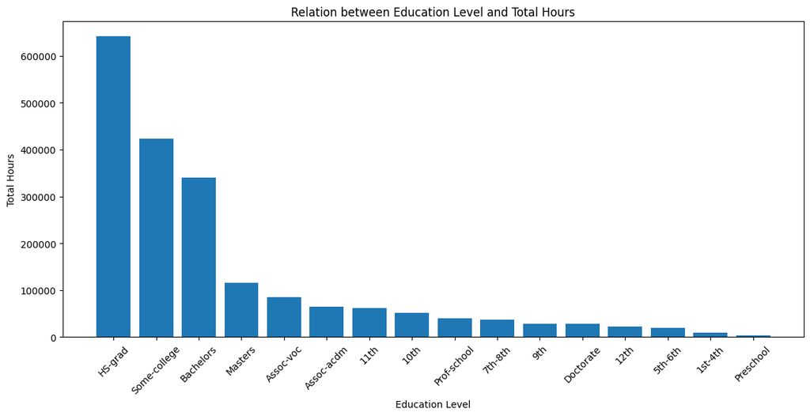

```python
# Plotting
plt.figure(figsize=(14, 6))
plt.bar(education_hours_relation['education'], education_hours_relation['hours-per-week'])

# Setting the axis, title
plt.xlabel('Education Level')
plt.ylabel('Total Hours')
plt.title('Relation between Education Level and Total Hours')
plt.xticks(rotation=45)

plt.show()
```

### Conclusion

From this graph we can analyze that the highest number of hours of work are contributed by the HS-Grad which might refer to the high school graduates, followed by some-college and then the holders of a bachelors.

This allows us to gather new and valuable information from the dataset which is not clearly defined and needs analysis to come to a conclusion and know more about this.